# 備忘録

## 2024年9月

### 0903

#### ASTRALの実行

`ASTRAL.sh.o26291746`の記述は以下の通り。

```bash
start at
2024年  7月 31日 水曜日 23:02:59 JST
Error occurred during initialization of VM
Could not reserve enough space for 629145600KB object heap
2024年  7月 31日 水曜日 23:03:00 JST
```

ヒープサイズ？を設定する値が大きすぎてエラーが出ているっぽい。

`ASTRAL.sh`を見ると確かに`-Xmx629145600K`となっていた。これを以下のように変更。

```bash
### ASTRAL.shの中身

#$ -S /bin/bash
#$ -cwd
#$ -l medium
#$ -pe def_slot 16
echo start at
date

java -Xmx2G -jar astral.5.7.8.jar \
    -i /home/kosukesano/tools/for_ASTRAL/Astral/data/modified_trees.nwk \
    -o /home/kosukesano/tools/for_ASTRAL/Astral/240903_result/out.tre \
    2>/home/kosukesano/tools/for_ASTRAL/Astral/240903_result/out.log

date
```

`-Xmx2G`にした。ついでに出力ファイルも`240903_result`とした。

```bash
kosukesano@at139:~/tools/for_ASTRAL/Astral$ mkdir 240903_result
```

`240903_result`を作成したのち、`ASTRAL.sh`を`qsub`で投げた。

**結果**

```bash
kosukesano@at139:~/tools/for_ASTRAL/Astral$ ls 240903_result/
out.log  out.tre
```

2つのファイルが出力された。それぞれのファイルの中身は以下の通り。

```bash
### out.logの中身

================== ASTRAL =====================

This is ASTRAL version 5.7.8
Gene trees are treated as unrooted
1518 trees read from /home/kosukesano/tools/for_ASTRAL/Astral/data/modified_trees.nwk
index0
All output trees will be *arbitrarily* rooted at Agra

======== Running the main analysis
Number of taxa: 6 (6 species)
Taxa: [Agra, Cass, Dpon, Smad, Sory, Tcas]
Taxon occupancy: {Cass=1518, Sory=1518, Tcas=1518, Agra=1518, Smad=1518, Dpon=1518}
Number of gene trees: 1518
0 trees have missing taxa
Calculating quartet distance matrix (for completion of X)
Species tree distances calculated ...
Building set of clusters (X) from gene trees
------------------------------
gradient0: 63
Number of Clusters after addition by distance: 63
calculating extra bipartitions to be added at level 1 ...
Adding to X using resolutions of greedy consensus ...
Limit for sigma of degrees:200
polytomy size limit : 4
discarded polytomies:  [3, 4]
Threshold 0.0:
Threshold 0.01:
Threshold 0.02:
Threshold 0.05:
Threshold 0.1:
Threshold 0.2:
polytomy of size 3; rounds with additions with at least 5 support: 0; clusters: 63
Threshold 0.3333333333333333:
polytomy of size 4; rounds with additions with at least 5 support: 0; clusters: 63
max k is :0
Number of Clusters after addition by greedy: 63
gradient0 in heuristiic: 63
partitions formed in 0.477 secs
Dynamic Programming starting after 0.477 secs
Using tree-based weight calculation.
Using polytree-based weight calculation.
Polytree max score: 22770
Polytree building time: 0.061 seconds.
Number of quartet trees in the gene trees: 22770
Size of largest cluster: 6
Greedy score: 11289
estimationFactor: 2.017007706617061
Sub-optimal score: 11289
Total Number of elements weighted: 136
Normalized score (portion of input quartet trees satisfied before correcting for multiple individuals): 0.4957839262187088
Optimization score: 11289
Optimal tree inferred in 0.694 secs.
(Cass,(Smad,(Dpon,(Agra,(Sory,Tcas)))));
Final quartet score is: 11289
Final normalized quartet score is: 0.4957839262187088
Extended species tree:
(Agra,((Sory,Tcas)1:0.7104118856165281,(Dpon,(Smad,Cass)0.63:0.017264705056582508)1:0.07499457563408858));
Weight calculation took 0.024812803 secs
ASTRAL finished in 1.732 secs
```

```bash
### out.treの中身

(Agra,((Sory,Tcas)1:0.7104118856165281,(Dpon,(Smad,Cass)0.63:0.017264705056582508)1:0.07499457563408858):0.0);
```

これをもとに書いた系統樹は以下の通り。

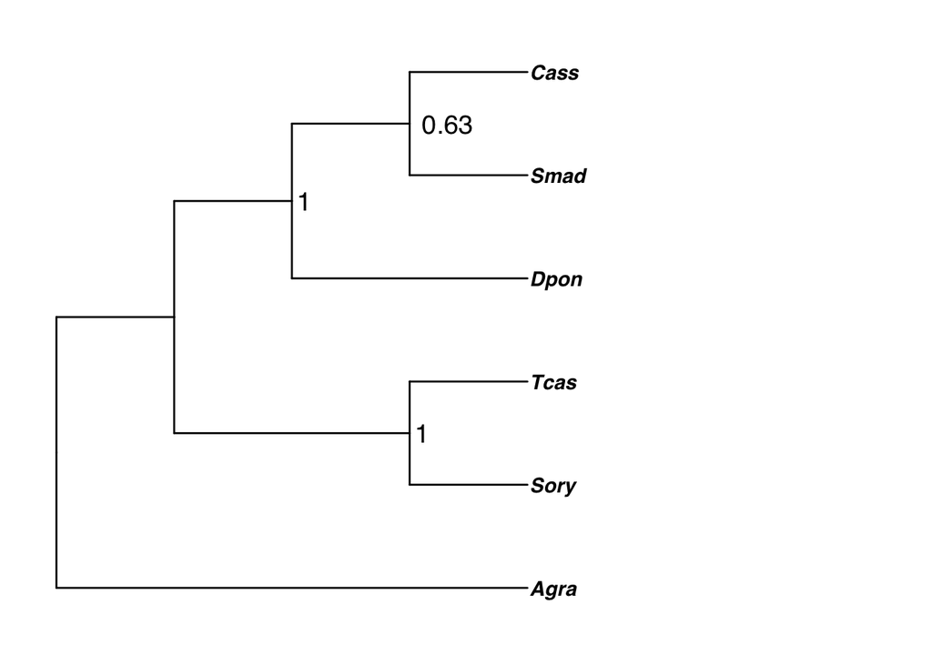

```r
tree = read.tree("/Users/kosukesano/bio/240903_ASTRAL.tre")

p=ggtree(tree)+
  xlim(0, 7)+
  theme(text = element_text(face = "italic"))+
  geom_tiplab(fontface = 4, linesize=3.0) + # Make tip labels italic
  geom_nodelab(hjust = -0.2, node = "internal", size = 5) +
  #geom_text(aes(label=node), hjust=-.2)+
  theme_tree()

p
```

A. grandisが最外群になってる〜！

`out.txt`の途中に出てた枝長などがない系統樹をコピーして`~bio/240903_ASTRAL_Optimal_tree.tre`として保存し描画してみる。

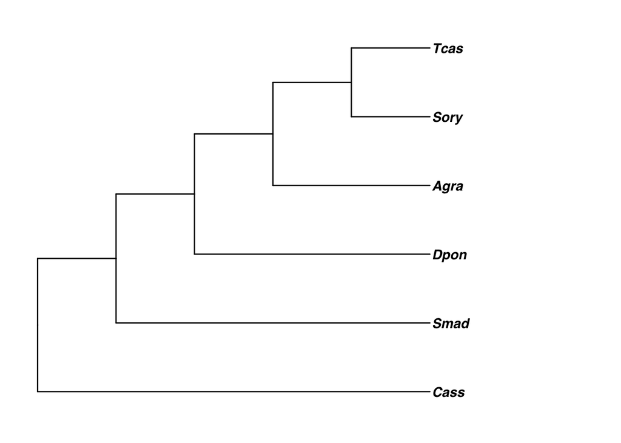

```r
tree2 = read.tree("/Users/kosukesano/bio/240903_ASTRAL_Optimal_tree.tre")
p=ggtree(tree2)+
  xlim(0, 7)+
  theme(text = element_text(face = "italic"))+
  geom_tiplab(fontface = 4, linesize=3.0) + # Make tip labels italic
  geom_nodelab(hjust = -0.2, node = "internal", size = 5) +
  #geom_text(aes(label=node), hjust=-.2)+
  theme_tree()

p
```

過去の系統樹はこちら

[figure not shown]

OrthoFinderとIQ-TREEで描いた系統樹

#### Dmelanogasterを加えた系統樹作成、それの準備としてのOrthofinder

外群が外群として機能していないので、一度絶対に外群だろうという昆虫（今回はキイロショウジョウバエ）を加えて系統樹を描いてみる。そのためにまず`OrthoFinder`を実行する。

`~/tools/for_orthofinder`ディレクトリに`Smad_Agra_Cass_Dpon_Sory_Tcas_Dmel_fasta_dir`ディレクトリを作成。その中に7種の昆虫のアミノ酸配列ファイルを格納した。

```bash
kosukesano@at139:~/tools/for_orthofinder$ ls Smad_Agra_Cass_Dpon_Sory_Tcas_Dmel_fasta_dir/
Agra.fasta  Cass.fasta  Dmel.fasta  Dpon.fasta  Smad.fasta  Sory.fasta  Tcas.fasta
kosukesano@at139:~/tools/for_orthofinder$
```

また、`seven_sp.sh`を作成した。

```bash
### seven_sp.shの中身

#$ -S /bin/bash
#$ -cwd
#$ -pe def_slot 5
#$ -l medium
#$ -l s_vmem=64G
#$ -l mem_req=64G
echo start at
date


singularity exec /usr/local/biotools/o/orthofinder:2.5.4--hdfd78af_0 orthofinder -f ~/tools/for_orthofinder/Smad_Agra_Cass_Dpon_Sory_Tcas_Dmel_fasta_dir -t 5 -a 5

date
```

これをqsubで投げた。

また、手動での系統樹作成アルゴリズムの１つである、`ManualPhylo_1.py`を作成し実行する。

まず、`~/tools/for_orthofinder/Smad_Agra_Cass_Dpon_Sory_Tcas_Dmel_fasta_dir/OrthoFinder/Results_Sep03`下に`ManualPhylo_data`ディレクトリを作成した。

```bash
kosukesano@at139:~/tools/for_orthofinder/Smad_Agra_Cass_Dpon_Sory_Tcas_Dmel_fasta_dir/OrthoFinder/Results_Sep03$ mkdir ManualPhilo_data
```

### 0904

7種の昆虫ゲノムを使った`OrthoFinder`が終わり、無事出力された。

`OrthoFinder`出力の系統樹はこんな感じ。

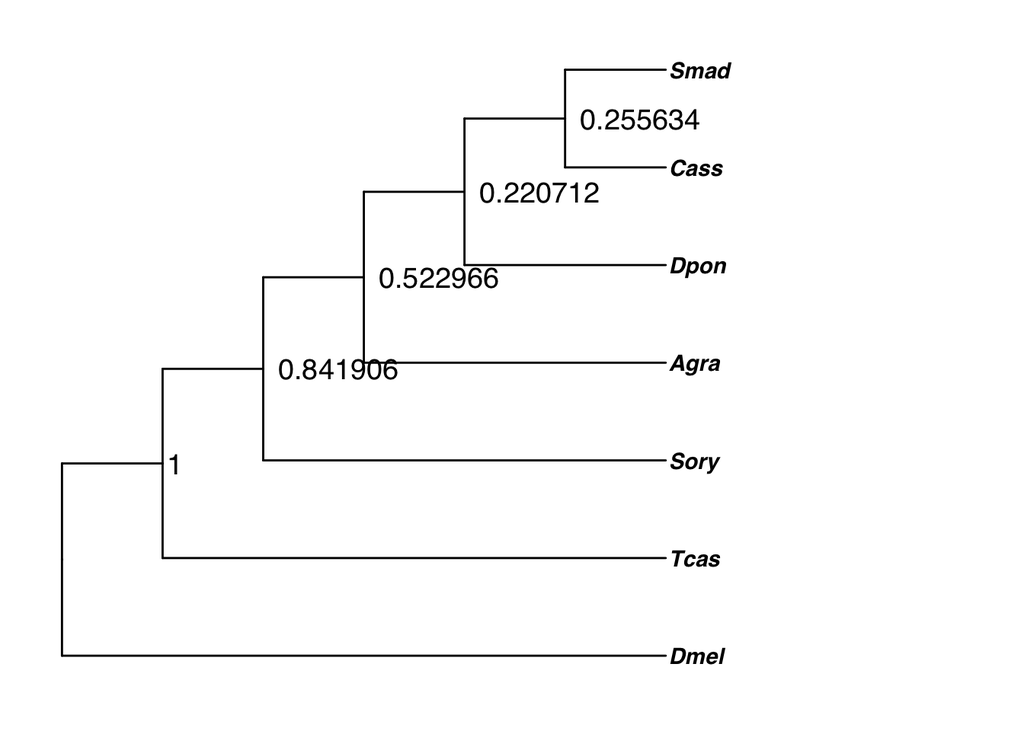

```r
tree3 = read.tree("/Users/kosukesano/bio/7sp.tre")
p=ggtree(tree3, branch.length = 'none')+
  xlim(0,9)+
  theme(text = element_text(face = "italic"))+
  geom_tiplab(fontface = 4, linesize=3.0) + # Make tip labels italic
  geom_nodelab(hjust = -0.1, node = "internal", size = 5) +
  #geom_text(aes(label=node), hjust=-.2)+
  theme_tree()
p
```

7種の昆虫ゲノムのアミノ酸配列fastaファイルを統合し、１つのファイルにする。

`~/tools/for_orthofinder/Smad_Agra_Cass_Dpon_Sory_Tcas_Dmel_fasta_dir/OrthoFinder/Results_Sep03/make_philo_tree`下で`fasta_concatinate.sh`を作成した。`fasta_concatinate.sh`の中身は以下の通り。

```bash
### fasta_concatinate.shの中身

#$ -S /bin/bash
#$ -cwd
#$ -pe def_slot 5
#$ -l medium
#$ -l s_vmem=64G
#$ -l mem_req=64G
echo start at
date

# Enter the directory containing the fasta files
filesout="/home/kosukesano/tools/for_orthofinder/Smad_Agra_Cass_Dpon_Sory_Tcas_Dmel_fasta_dir"  ## Please replace with the actual directory containing the fasta files

# Define the output directory and output file
new="output_directory"
mkdir -p $new

# Concatenate all fasta files into one file
for file in "$filesout"/*.fasta; do
    cat "$file" >> "./${new}/all_seq.fa"
done


date
```

これを作業ノードで実行権限を与えて実行した。

```bash
kosukesano@at139:~/tools/for_orthofinder/Smad_Agra_Cass_Dpon_Sory_Tcas_Dmel_fasta_dir/OrthoFinder/Results_Sep03/make_philo_tree$ chmod +x fasta_concatinate.sh
kosukesano@at139:~/tools/for_orthofinder/Smad_Agra_Cass_Dpon_Sory_Tcas_Dmel_fasta_dir/OrthoFinder/Results_Sep03/make_philo_tree$ ./fasta_concatinate.sh
```

結果として、`~/tools/for_orthofinder/Smad_Agra_Cass_Dpon_Sory_Tcas_Dmel_fasta_dir/OrthoFinder/Results_Sep03/make_philo_tree/output_directory`に`all_seq.fa`ができた。

```bash
kosukesano@at139:~/tools/for_orthofinder/Smad_Agra_Cass_Dpon_Sory_Tcas_Dmel_fasta_dir/OrthoFinder/Results_Sep03/make_philo_tree/output_directory$ ls
all_seq.fa
```

続いて、`~/tools/for_orthofinder/Smad_Agra_Cass_Dpon_Sory_Tcas_Dmel_fasta_dir/OrthoFinder/Results_Sep03/make_philo_tree`下で`ManualPhylo_2.py`を作成し実行した。

`ManualPhylo_2.py`の中身は以下の通り。**0718のManualPhylo_2.pyではOGがきちんと抽出できないので注意！**

```bash
### ManualPhylo_2.pyの中身

##ManualPhylo_1.pyの続き

import sys
from Bio import SeqIO

path = "../ManualPhylo_data/"

fasta_in = sys.argv[1]                                  #１番目の引数には上記のall_seq.faなどfastaファイルを指定する
query_in = sys.argv[2]                                  #２番目の引数には上記のOG_list.txtなどオーソログファイルを指定する

for q in open(query_in, "r"):                                           #オーソログファイルを開いて1行づつ読み込む
        query = q.split()                                                       #スペース毎に切りとってリスト形式でqueryに保存する
        f = open(path + query[0], 'w')                                  #最初の列(OG名）と同じ名前のファイルを作成する
        for record in SeqIO.parse(fasta_in, 'fasta'):   #fastaファイルを開くSeqIOを使ってパースする(1項目づつ読み込む）
                id_part = record.id                                     #fastaのID部分を読み込む
                desc_part = record.description                  #fastaのdescription部分を読み込む
                seq = record.seq                                        #fastaの配列部分を読み込む
                for i in range(len(query)):                         #オーソログファイル中の各OGに含まれる配列数を数えて、その分繰り返す(python2の人はrange を x rangeにする)
                        if id_part == query[i] or desc_part == query[i] :                   #オーソログファイルの配列descriptionとfastaの配列descriptionが一致したら、、、
                                fasta_seq = '>' + id_part + ' ' + desc_part + '\n' + seq + '\n'         #fasta形式に整え
                                print(fasta_seq)                                        #標準出力にfastaを出力（進行状況把握用）
                                f.write(str(fasta_seq))                             #各OGファイルにfastaを出力
        f.close()

##できたOGファイルは、align.shやOG_list.txtと同じ場所に
##align.shのある場所までいき、作動。cwdを231016/ManualPhylo_dataにしないとtrimalが作動せず、イライラ
```

これにより**630個**のSCOが抽出された。

```bash
kosukesano@at139:~/tools/for_orthofinder/Smad_Agra_Cass_Dpon_Sory_Tcas_Dmel_fasta_dir/OrthoFinder/Results_Sep03/ManualPhylo_data$ ls -1 | wc -l
632

### ls -1 | wc -lでファイル数をカウント。OG_list.txtとspecies_list.txtがあるので-2する。
```

続いて、`MAFFT`と`trimAl`によってOGをアライメントする。

まず`MAFFT`と`trimAl`の環境を立ち上げる。

```bash
source ~/tools/pyenv_env/ManualPhilo_profile
```

続いて、`~/tools/for_orthofinder/Smad_Agra_Cass_Dpon_Sory_Tcas_Dmel_fasta_dir/OrthoFinder/Results_Sep03/ManualPhylo_data`下に`align.sh`を作成、実行する。

`align.sh`の中身は以下の通り。

```bash
### align.shの中身


#!/bin/sh
#$ -S /bin/bash
#$ -cwd
#$ -v PATH
awk '{print($1)}' $1 | while read x; do #引数に前述のOG_list.txtなどのOGリストを指定する。
    mafft --auto $x > $x.maffted.fa
    trimal -in $x.maffted.fa -out $x.maffted.trimed.fa -htmlout $x.maffted.trimed.fa.html -automated1
done
```

実行コマンドは以下の通り

```bash
(MPT) kosukesano@at138:~/tools/for_orthofinder/Smad_Agra_Cass_Dpon_Sory_Tcas_Dmel_fasta_dir/OrthoFinder/Results_Sep03/ManualPhylo_data$ sh align.sh OG_list.txt
```

続いて`~/tools/for_orthofinder/Smad_Agra_Cass_Dpon_Sory_Tcas_Dmel_fasta_dir/OrthoFinder/Results_Sep03/make_philo_tree`にて`ManualPhylo_3.py`を作成、実行した。

`ManualPhylo_3.py`の中身は以下の通り。

```bash
### ManualPhylo_3.pyの中身


##align.shした後

#!/usr/bin/env python
# -*- coding: utf-8 -*-

import sys
from Bio import SeqIO

path = "../ManualPhylo_data/"

query_in = sys.argv[1]                            #1番目の引数には上記のOG_list.txtなどオーソログファイルを指定する
species_in = sys.argv[2]                          #2番目の引数にはOG_list.txtと同じ順番で種名を記述したファイルを指定する

sp_list = []
for sp in open(species_in, "r"):                     #種名ファイルを開く
        sp_list.extend(sp.split())                            #スペース毎に切りとってリスト形式でsp_listに保存する

for q in open(query_in, "r"):                     #オーソログファイルを開いて1行づつ読み込む
        query = q.split()                             #スペース毎に切りとってリスト形式でqueryに保存する

        f = open(path + query[0]+".maffted.trimed.edit.fa", 'w')
        for record in SeqIO.parse(path + query[0]+".maffted.trimed.fa", 'fasta'): #fastaファイルを開くSeqIOを使ってパースする(1項目づつ読み込む）
                desc_part = record.description            #fastaのdescription部分を読み込む
                seq = record.seq                          #fastaの配列部分を読み込む
                desc_part_new = desc_part.split()[0]

                for i in range(len(query)-1):              #オーソログファイル中の各OGに含まれる配列数を数えて、その分繰り返す

                        if desc_part_new == query[i+1] :            #オーソログファイルの配列descriptionとfastaの配列descriptionが一致したら、、、
                                fasta_seq = '>' + sp_list[i] + '\n' + seq + '\n'     #配列名を該当する種名に置き換えて、fasta形式に整えて
                                print(fasta_seq)                  #標準出力にfastaを出力（進行状況把握用）
                f.write(str(fasta_seq))           #各OGファイルにfastaを出力
        f.close()

##scorpionでnano run.nexを変更し、以下を実行
##iqtree –sp run.nex –nt AUTO –bb 1000
~
```

実行コマンド

```bash
(MPT) kosukesano@at138:~/tools/for_orthofinder/Smad_Agra_Cass_Dpon_Sory_Tcas_Dmel_fasta_dir/OrthoFinder/Results_Sep03/make_philo_tree$ python ManualPhylo_3.py ../ManualPhylo_data/OG_list.txt ../ManualPhylo_data/species_list.txt
```

続いて`~/tools/for_orthofinder/Smad_Agra_Cass_Dpon_Sory_Tcas_Dmel_fasta_dir/OrthoFinder/Results_Sep03/ManualPhylo_data`下に`makealltree.sh`を作成、qsubでジョブとして投げた。

`makealltree.sh`の中身は以下の通り。

```bash
### makealltree.shの中身

#$ -S /bin/bash
#$ -cwd
#$ -l intel
#$ -pe def_slot 16
echo start at
date

# Singularityイメージのパスを指定
SINGULARITY_IMAGE="/usr/local/biotools/i/iqtree:2.3.3--h21ec9f0_0"

# 作業ディレクトリに移動
cd ~/tools/for_orthofinder/Smad_Agra_Cass_Dpon_Sory_Tcas_Dmel_fasta_dir/OrthoFinder/Results_Sep03/ManualPhylo_data
# 出力ファイル

output_file="all_trees.nwk"

# 既存の出力ファイルを削除
if [ -f $output_file ]; then
    rm $output_file
fi

# *.maffted.trimed.edit.fa ファイルを処理
for file in *.maffted.trimed.edit.fa; do
    # ファイル名から拡張子を除いたベース名を取得
    base_name=$(basename $file .maffted.trimed.edit.fa)

    # Singularityを使用してIQ-TREEを実行して系統樹を作成
    singularity exec -e $SINGULARITY_IMAGE iqtree2 -s $file -nt AUTO -bb 1000 -cptime 600 -pre ${base_name}

    # 作成された系統樹ファイル (.treefile) を output_file に追加
    if [ -f ${base_name}.treefile ]; then
        echo -n "${base_name}: " >> $output_file
        cat ${base_name}.treefile >> $output_file
        echo "" >> $output_file
    else
        echo "Error: ${base_name}.treefile not found" >&2
    fi
done

echo "All trees have been written to $output_file"

date
```

### 0905

昨日の`IQ-TREE`はうまくいっており、最終出力の`all_trees.nwk`も出力されていた。

```bash
(MPT) kosukesano@at138:~/tools/for_orthofinder/Smad_Agra_Cass_Dpon_Sory_Tcas_Dmel_fasta_dir/OrthoFinder/Results_Sep03/ManualPhylo_data$ ls all_trees.nwk
all_trees.nwk
```

これを`ASTRAL`用のディレクトリにコピー。

`~/tools/for_ASTRAL/Astral/data`には以前のインプットファイルがあったため、`6sp`と`7sp`というディレクトリを作りそこに格納。

```bash
kosukesano@at137:~/tools/for_ASTRAL/Astral/data$ ls
all_trees.nwk  modified_trees.nwk  modify.py
kosukesano@at137:~/tools/for_ASTRAL/Astral/data$ mkdir 6sp
kosukesano@at137:~/tools/for_ASTRAL/Astral/data$ ls
6sp  all_trees.nwk  modified_trees.nwk  modify.py
kosukesano@at137:~/tools/for_ASTRAL/Astral/data$ mv *.nwk 6sp
kosukesano@at137:~/tools/for_ASTRAL/Astral/data$ ls
6sp  modify.py
kosukesano@at137:~/tools/for_ASTRAL/Astral/data$ mkdir 7sp
kosukesano@at137:~/tools/for_ASTRAL/Astral/data$ ls
6sp  7sp  modify.py
kosukesano@at137:~/tools/for_ASTRAL/Astral/data$
```

`7sp`の方に今回の`all_trees.nwk`をコピーし、`modify.py`でOG番号を切り取った。

`modify.py`の中身は以下の通り。

```bash
### modify.pyの中身

# 元のファイルと新しいファイルのパスを設定
input_file_path = '7sp/all_trees.nwk'
output_file_path = '7sp/modified_trees.nwk'

# 元のファイルを開いて処理
with open(input_file_path, 'r') as infile, open(output_file_path, 'w') as outfile:
    for line in infile:
        # 行を ': ' で分割し、要素が2つ以上の場合のみ処理
        parts = line.split(': ', 1)
        if len(parts) > 1:
            modified_line = parts[1]
            # 新しいファイルに書き込み
            outfile.write(modified_line)
```

これを使って`ASTRAL`を実行。使ったスクリプトは以下の通り。

```bash
### ASTRAL.shの中身

#$ -S /bin/bash
#$ -cwd
#$ -l medium
#$ -pe def_slot 16
echo start at
date

java -Xmx2G -jar astral.5.7.8.jar \
    -i /home/kosukesano/tools/for_ASTRAL/Astral/data/7sp/modified_trees.nwk \
    -o /home/kosukesano/tools/for_ASTRAL/Astral/240905_result/out.tre \
    2>/home/kosukesano/tools/for_ASTRAL/Astral/240905_result/out.log

date
```

これをqsubで投げた。

#### 欠失１つを許した`ASTRAL`の作成

`~/tools/for_orthofinder/Smad_Agra_Cass_Dpon_Sory_Tcas_fasta_dir/OrthoFinder/Results_Jun25/Orthogroups`下で`SCOwiith0tyusyutu.py`を作成、実行した。

```bash
### SCOwiith0tyusyutu.pyの中身


import pandas as pd

# ファイルを読み込む
file_path = "Orthogroups.GeneCount.tsv"
df = pd.read_csv(file_path, sep="\t")

# 各列が1か0で、1つの列が0で他が全て1の行を抽出
filtered_df = df[
    ((df['Agra'] == 1) & (df['Cass'] == 1) & (df['Dpon'] == 1) & (df['Smad'] == 1) & (df['Sory'] == 1) & (df['Tcas'] == 1)) |
    ((df['Agra'] == 0) & (df['Cass'] == 1) & (df['Dpon'] == 1) & (df['Smad'] == 1) & (df['Sory'] == 1) & (df['Tcas'] == 1)) |
    ((df['Agra'] == 1) & (df['Cass'] == 0) & (df['Dpon'] == 1) & (df['Smad'] == 1) & (df['Sory'] == 1) & (df['Tcas'] == 1)) |
    ((df['Agra'] == 1) & (df['Cass'] == 1) & (df['Dpon'] == 0) & (df['Smad'] == 1) & (df['Sory'] == 1) & (df['Tcas'] == 1)) |
    ((df['Agra'] == 1) & (df['Cass'] == 1) & (df['Dpon'] == 1) & (df['Smad'] == 0) & (df['Sory'] == 1) & (df['Tcas'] == 1)) |
    ((df['Agra'] == 1) & (df['Cass'] == 1) & (df['Dpon'] == 1) & (df['Smad'] == 1) & (df['Sory'] == 0) & (df['Tcas'] == 1)) |
    ((df['Agra'] == 1) & (df['Cass'] == 1) & (df['Dpon'] == 1) & (df['Smad'] == 1) & (df['Sory'] == 1) & (df['Tcas'] == 0))
]

# Orthogroup 列のみを抽出
filtered_df = filtered_df[['Orthogroup']]

# 抽出したデータを新しいファイルに保存 (ヘッダー削除) 拡張子を .txt に変更
output_file_path = "Orthogroups.GeneCount.SingleCopyWithOneZeroOrtholog.txt"
filtered_df.to_csv(output_file_path, sep="\t", index=False, header=False)


print(f"抽出されたデータが {output_file_path} に保存されました。")
```

`~/tools/for_orthofinder/Smad_Agra_Cass_Dpon_Sory_Tcas_fasta_dir/OrthoFinder/Results_Jun25`下に`SCOwithOneZero_Manualphylo_data`を作成、Manualphylo_1,2とalign.shを実行した。

```bash
kosukesano@at137:~/tools/for_orthofinder/Smad_Agra_Cass_Dpon_Sory_Tcas_fasta_dir/OrthoFinder/Results_Jun25/SCOwithOneZero_Manualphylo_data$ ls ManualPhylo_*
ManualPhylo_1.py  ManualPhylo_2.py  ManualPhylo_3.py
```

```bash
### ManualPhylo_1.pyの実行
(MPT) kosukesano@at138:~/tools/for_orthofinder/Smad_Agra_Cass_Dpon_Sory_Tcas_fasta_dir/OrthoFinder/Results_Jun25/SCOwithOneZero_Manualphylo_data$ python ManualPhylo_1.py

### ManualPhylo_2.pyの実行
(MPT) kosukesano@at138:~/tools/for_orthofinder/Smad_Agra_Cass_Dpon_Sory_Tcas_fasta_dir/OrthoFinder/Results_Jun25/SCOwithOneZero_Manualphylo_data$ python ManualPhylo_2.py ~/tools/for_orthofinder/make_philo_tree/output_directory/all_seq.fa OG_list.txt

### align.shの実行
(MPT) kosukesano@at138:~/tools/for_orthofinder/Smad_Agra_Cass_Dpon_Sory_Tcas_fasta_dir/OrthoFinder/Results_Jun25/SCOwithOneZero_Manualphylo_data$ sh align.sh OG_list.txt
```

### 0907

`~/tools/for_orthofinder/Smad_Agra_Cass_Dpon_Sory_Tcas_fasta_dir/OrthoFinder/Results_Jun25/SCOwithOneZero_Manualphylo_data`下で`Manualphylo_3.py`を実行した。

```bash
(MPT) kosukesano@at138:~/tools/for_orthofinder/Smad_Agra_Cass_Dpon_Sory_Tcas_fasta_dir/OrthoFinder/Results_Jun25/SCOwithOneZero_Manualphylo_data$ python3 ManualPhylo_3.py OG_list.txt species_list.txt
```

同じディレクトリに`makealltree.sh`をコピーし、パスを書き換えて実行した。

```bash
(MPT) kosukesano@at138:~/tools/for_orthofinder/Smad_Agra_Cass_Dpon_Sory_Tcas_fasta_dir/OrthoFinder/Results_Jun25/SCOwithOneZero_Manualphylo_data$ cp ~/tools/for_orthofinder/Smad_Agra_Cass_Dpon_Sory_Tcas_Dmel_fasta_dir/OrthoFinder/Results_Sep03/ManualPhylo_data/makealltree.sh ../SCOwithOneZero_Manualphylo_data/
(MPT) kosukesano@at138:~/tools/for_orthofinder/Smad_Agra_Cass_Dpon_Sory_Tcas_fasta_dir/OrthoFinder/Results_Jun25/SCOwithOneZero_Manualphylo_data$ ls makealltree.sh
makealltree.sh
(MPT) kosukesano@at138:~/tools/for_orthofinder/Smad_Agra_Cass_Dpon_Sory_Tcas_fasta_dir/OrthoFinder/Results_Jun25/SCOwithOneZero_Manualphylo_data$ less makealltree.sh
(MPT) kosukesano@at138:~/tools/for_orthofinder/Smad_Agra_Cass_Dpon_Sory_Tcas_fasta_dir/OrthoFinder/Results_Jun25/SCOwithOneZero_Manualphylo_data$ nano makealltree.sh
(MPT) kosukesano@at138:~/tools/for_orthofinder/Smad_Agra_Cass_Dpon_Sory_Tcas_fasta_dir/OrthoFinder/Results_Jun25/SCOwithOneZero_Manualphylo_data$ qsub_beta makealltree.sh
Your job 26698378 ("makealltree.sh") has been submitted
```

書き換えた`makealltree.sh`は以下の通り。

```bash
### makealltreeの中身

#$ -S /bin/bash
#$ -cwd
#$ -l intel
#$ -pe def_slot 16
echo start at
date

# Singularityイメージのパスを指定
SINGULARITY_IMAGE="/usr/local/biotools/i/iqtree:2.3.3--h21ec9f0_0"

# 作業ディレクトリに移動
cd ~/tools/for_orthofinder/Smad_Agra_Cass_Dpon_Sory_Tcas_fasta_dir/OrthoFinder/Results_Jun25/SCOwithOneZero_Manualphylo_data
# 出力ファイル

output_file="all_trees.nwk"

# 既存の出力ファイルを削除
if [ -f $output_file ]; then
    rm $output_file
fi

# *.maffted.trimed.edit.fa ファイルを処理
for file in *.maffted.trimed.edit.fa; do
    # ファイル名から拡張子を除いたベース名を取得
    base_name=$(basename $file .maffted.trimed.edit.fa)

    # Singularityを使用してIQ-TREEを実行して系統樹を作成
    singularity exec -e $SINGULARITY_IMAGE iqtree2 -s $file -nt AUTO -bb 1000 -cptime 600 -pre ${base_name}

    # 作成された系統樹ファイル (.treefile) を output_file に追加
    if [ -f ${base_name}.treefile ]; then
        echo -n "${base_name}: " >> $output_file
        cat ${base_name}.treefile >> $output_file
        echo "" >> $output_file
    else
        echo "Error: ${base_name}.treefile not found" >&2
    fi
done

echo "All trees have been written to $output_file"

date
```

### 0908

前日のジョブをまちがって上書きしてしまった……。

すべて`qdel`して改めて`qsub`

### 0909

`IQ-TREE`のジョブは無事できていた。最終出力の`all_trees.nwk`を`ASTRAL`用のディレクトリにコピー。

`~/tools/for_ASTRAL/Astral/data/6sp_withOneZero`というディレクトリを作りそこに格納。`modify.py`で OG番号を切り取った。

これを使って`ASTRAL`を実行。使ったスクリプトは以下の通り。

```bash
### ASTRAL.shの中身

#$ -S /bin/bash
#$ -cwd
#$ -l medium
#$ -pe def_slot 16
echo start at
date

java -Xmx2G -jar astral.5.7.8.jar \
    -i /home/kosukesano/tools/for_ASTRAL/Astral/data/6sp_withOneZero/modified_trees.nwk \
    -o /home/kosukesano/tools/for_ASTRAL/Astral/240909_result/out.tre \
    2>/home/kosukesano/tools/for_ASTRAL/Astral/240909_result/out.log

date
```

### 0910

`240910_result`を作ってなかったのでエラー……。

`mkdir`で作り直してもう一度動かす。ついでに作業ノードで実行権限を付与して行ってみる。

```bash
kosukesano@at138:~/tools/for_ASTRAL/Astral$ mkdir 240910_result
kosukesano@at138:~/tools/for_ASTRAL/Astral$ nano ASTRAL.sh
kosukesano@at138:~/tools/for_ASTRAL/Astral$ chmod +x ASTRAL.sh
kosukesano@at138:~/tools/for_ASTRAL/Astral$ ./ASTRAL.sh
start at
Tue Sep 10 10:24:33 JST 2024
Tue Sep 10 10:24:34 JST 2024
kosukesano@at138:~/tools/for_ASTRAL/Astral
```

1秒でできた。

出力ファイルもしっかりある。今後はジョブとして投げなくて良さそう。

```bash
kosukesano@at138:~/tools/for_ASTRAL/Astral/240910_result$ ls
out.log  out.tre
kosukesano@at138:~/tools/for_ASTRAL/Astral/240910_result$
```

出力ファイル`out.txt`をよく見てみる。

```bash
======== Running the main analysis
Number of taxa: 6 (6 species)
Taxa: [Agra, Cass, Dpon, Smad, Sory, Tcas]
Taxon occupancy: {Cass=1950, Sory=1950, Tcas=1518, Agra=1950, Smad=1950, Dpon=1950}
Number of gene trees: 1950
432 trees have missing taxa
Calculating quartet distance matrix (for completion of X)
Species tree distances calculated ...
Will attempt to complete bipartitions from X before adding using a distance matrix.
Building set of clusters (X) from gene trees
```

Tcasしか欠失分が取れていない？

**系統樹の描画**

最終出力である`out.tre`を`240910_ASTRAL.tre`としてコピー、それを元に系統樹を描画。

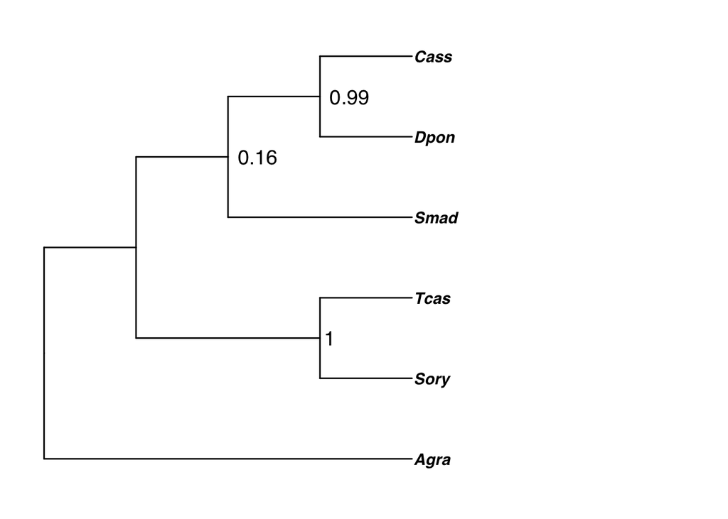

```r
tree4 = read.tree("/Users/kosukesano/bio/240910_ASTRAL.tre")

p=ggtree(tree4)+
  xlim(0, 7)+
  theme(text = element_text(face = "italic"))+
  geom_tiplab(fontface = 4, linesize=3.0) + # Make tip labels italic
  geom_nodelab(hjust = -0.2, node = "internal", size = 5) +
  #geom_text(aes(label=node), hjust=-.2)+
  theme_tree()
p
```

**6種のSCOについて、欠失を１つまで許した時の系統樹**

前の系統樹と比べると、マダラとキクイムシの位置がずれている。

`out.txt`の中にある系統樹もコピーし、`240910_ASTRAL_Optimal_tree.tre`として描画。

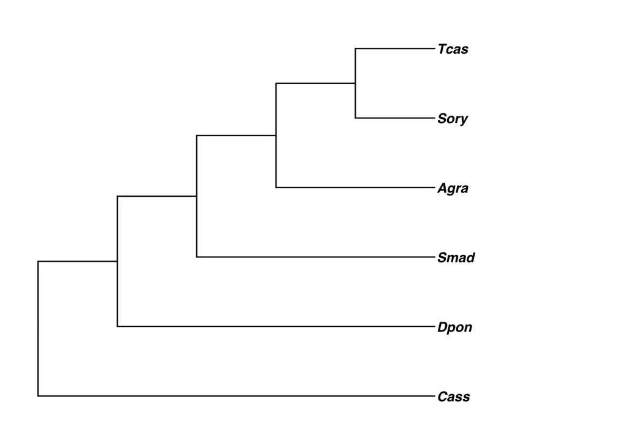

```r
tree5= read.tree("/Users/kosukesano/bio/240910_ASTRAL_Optimal_tree.tre")
p=ggtree(tree5)+
  xlim(0, 7)+
  theme(text = element_text(face = "italic"))+
  geom_tiplab(fontface = 4, linesize=3.0) + # Make tip labels italic
  geom_nodelab(hjust = -0.2, node = "internal", size = 5) +
  #geom_text(aes(label=node), hjust=-.2)+
  theme_tree()
p
```

**SCOの欠失部分がうまく取れていない件について**

```bash
Orthogroup      Agra    Cass    Dpon    Smad    Sory    Tcas    Total
OG0010273       1       1       1       1       1       0       5
OG0010276       1       1       1       1       1       0       5
OG0010278       1       0       1       1       1       1       5
```

```bash
### OG0010273.maffted.fnaの中身

>XP_050293049.1 XP_050293049.1 ras-related protein Rab-27A [Anthonomus grandis grandis]
--MEYDYLIKFLALGDSGVGKTSFLYQYTDSSFNSRFISTVGIDFREKRLIYQAKGRSYR
VHLQLWDTAGQERFRSLTTAFYRDAMGFILIFDLTNEQSFLEIRNWINQLRIHAYCDTPD
IVLCGNKADLEDRRVVSEWKAREFAELNGLPYLETSAATGQNVSRSIETLLERVMIRMET
AVDSAMLPTHRDNFRNPLRVGLNTNYSAQKCSC
>XP_019755005.1 XP_019755005.1 ras-related protein Rab-27A [Dendroctonus ponderosae]
MRMDYDYLIKFLALGDSGVGKTSFLYQYTDGTFNSRFISTVGIDFREKRLIYQSKGRNYR
VHLQLWDTAGQERFRSLTTAFYRDAMGFLLLFDLTNERSFLEIRNWIEQLRVHAYCDTPD
IVLCGNKADIEDRRVVSEWKAREFAEINGLPYLETSAATGQNISRAIETLLEKVMYRMET
AVDMAMLPNRRGNPGDHSQIDLSAPSSAQKCLC
>g2477.t1 g2477.t1
--MEYDYLIKFLALGDSGVGKTSFLHQYTDGTFNSRFISTVGIDFREKRLVYQSKGRNYR
VHLQLWDTAGQERFRSLTTAFYRDAMGFLLLFDLTNEQSFLEIRNWIEQLRVHAYCDTPD
VILCGNKADLEDRRVITEWKAREFAESNGLPYLETSAATGQNVSRAIETLLEKVMYRMET
AVDMAMLPNRRGNLKEVLKVDLNASPSAQKCLC
>XP_030762023.1 XP_030762023.1 ras-related protein Rab-27A [Sitophilus oryzae]
--MDYDYLIKFLALGDSGVGKTSFLYQYTDGTFNSRFISTVGIDFREKRMIYQSKGRNYR
VHLQLWDTAGQERFRSLTTAFYRDAMGFLLLFDLTNEHSFLEIRNWIEQLRLHAYCDTPD
IVLCGNKADLEDRRVVTEWRAREFAEINGLPYLETSAATGQNVSRAVETLLEKVMLRMET
AVDMAMVPGQSGKFKDTGEFMLRSSSPAQKCTC
>XP_967715.1 XP_967715.1 PREDICTED: ras-related protein Rab-27A [Tribolium castaneum]
--MDYDYLIKFLALGDSGVGKTSFLYQYTDGLFNSRFISTVGIDFREKRLLYQSKGRNHR
VHLQLWDTAGQERFRSLTTAFYRDAMGFLLLFDLTNEQSFLEIRNWVEQLRLHAYCDCPD
VVLCGNKADLEDRRIITEWRAREMAEKLGLVYLETSAATGQNVSRAVETLLEKVMIRMET
AVDRAMLPGRRGRPRDPNDVDFNAP-PTHNCTC
```

Cass以外の5種の配列が記述されている。

```bash
### OG0010278.maffted.trimed.edit.faの中身

>Agra
MEYDYLIKFLALGDSGVGKTSFLYQYTDSSFNSRFISTVGIDFREKRLIYQAKGRSYRVH…
>Cass
MDYDYLIKFLALGDSGVGKTSFLYQYTDGTFNSRFISTVGIDFREKRLIYQSKGRNYRVH…
>Dpon
MEYDYLIKFLALGDSGVGKTSFLHQYTDGTFNSRFISTVGIDFREKRLVYQSKGRNYRVH…
>Smad
MDYDYLIKFLALGDSGVGKTSFLYQYTDGTFNSRFISTVGIDFREKRMIYQSKGRNYRVH…
>Sory
MDYDYLIKFLALGDSGVGKTSFLYQYTDGLFNSRFISTVGIDFREKRLLYQSKGRNHRVH…
```

Cassが入り、その分Tcasが消えてる。種名ラベルの記述がミスっている？

### 0911

`~/tools/for_orthofinder/Smad_Agra_Cass_Dpon_Sory_Tcas_fasta_dir/OrthoFinder/Results_Jun25/SCOwithOneZero_Manualphylo_data/`下に`test`ディレクトリを作り、色々検証。

`OG_list.txt`と`species_list.txt`、`Manualphylo_*`ファイルをコピーした。

**`Manualphylo_2.py`の実行**

```bash
(MPT) kosukesano@at138:~/tools/for_orthofinder/Smad_Agra_Cass_Dpon_Sory_Tcas_fasta_dir/OrthoFinder/Results_Jun25/SCOwithOneZero_Manualphylo_data/test$ python ManualPhylo_2.py ~/tools/for_orthofinder/make_philo_tree/output_directory/all_seq.fa OG_list.txt
```

`Manualphylo_2.py`を実行すると、`OG0008034`のようなOGごとの配列が記録されたファイルができる。

```bash
(MPT) kosukesano@at138:~/tools/for_orthofinder/Smad_Agra_Cass_Dpon_Sory_Tcas_fasta_dir/OrthoFinder/Results_Jun25/SCOwithOneZero_Manualphylo_data/test$ ls
ManualPhylo_1.py  ManualPhylo_3.py  OG0008034  OG0008036  OG0008039  OG0008041  OG0008043  OG0008045  OG0008048  OG_list.txt  species_list.txt
ManualPhylo_2.py  OG0008033         OG0008035  OG0008037  OG0008040  OG0008042  OG0008044  OG0008046  OG0008049  align.sh
(MPT) kosukesano@at138:~/tools/for_orthofinder/Smad_Agra_Cass_Dpon_Sory_Tcas_fasta_dir/OrthoFinder/Results_Jun25/SCOwithOneZero_Manualphylo_data/test$
```

上記のは途中でCtr＋Cを押して終了させた。

`OG0010273`のみをコピーし、残りは消去。

**`align_sh`の実行**

```bash
kosukesano@at138:~/tools/for_orthofinder/Smad_Agra_Cass_Dpon_Sory_Tcas_fasta_dir/OrthoFinder/Results_Jun25/SCOwithOneZero_Manualphylo_data/test$ source ~/tools/pyenv_env/ManualPhilo_profile
(MPT) kosukesano@at138:~/tools/for_orthofinder/Smad_Agra_Cass_Dpon_Sory_Tcas_fasta_dir/OrthoFinder/Results_Jun25/SCOwithOneZero_Manualphylo_data/test$ sh align.sh OG_list.txt
```

`align_sh`を実行すると、`*maffted.fa`、`*maffted.trimed.fa`ができる。`*maffted.fa`はヘッダーがフルで入っているが、`*maffted.trimed.fa`はヘッダー部分は遺伝子IDのみになっている。

```bash
### OG0010273.maffted.faの中身

>XP_050292831.1 XP_050292831.1 uncharacterized protein LOC126733540 [Anthonomus grandis grandis]
MPFNVMIQLCNITRQSKLFQRNFYLPLLKPLSPKDALRIHVITGKDVLSKALEHWIPVLE
EYSARVARKRHMPKGKGKKRLRKKESMKYLMPFFDSGMDNHAKLENVCNRKSKGRGQCYT
YYIPEKKCTLVFTHQMERAIRDKDIIDVIIAQRHEKILVKMRDGTKVVMPLSPYNGKGPL
YRGEGWTRKDIEEYHHHGRETFSIAQLFEAKEAGIEEWELEMMRMANKRKKKMKGEDTRD
WKEMLAATASNMDWDAFEEETKQIVEQANEPVNDEPIAMQLDNIDKTCDVIDKLKAAGEE
VLSLLPTMPEIPEILKVIKDQSELTEIANISGARVNLKASAERPGERFVPGQMVTSEEGD
LFVPGQTILNESGVKEYTPGFTVLLDNEPTLIPGLVMGNDPDKSMFLPGESTITESGELQ
FAATDEDILPHVDTPPP-EKEVEEIELEEEQNSEDEEIEQRPPPKPKRKELTYERPKREF
KTENMGPKRRVRGPKKVAEPAPAPAPPTLE--RRPTIIIEAKLFNLQTPTFEKDILEQQK
ERVEAFKEKTGKEEARLNKYRLELRMKAKKMRESLPPPPIYEPLEPVRKSEKLRELEKSI
KKGRFFEADHKKYITNEYTE-KFHWIDTYQYKKVFDTVGIMRHRVWKPVYS--H
>CAG9762300.1 CAG9762300.1 unnamed protein product [Ceutorhynchus assimilis]
MPFNVMIQLCNITRQS----------------------------KDVLAKALEHWIPVLE
DHASRVARRRHMPKGKGKKRQRKKESMRYLTPFFDEMMDNHGRLENMIIRKPKGRGQCYT
YYIPEKKCTLVLTHQFEKAIRDKDIVDIVIAQRHEKIIVKLRDGLKVVMPLSPYSGKAPF
YRGEGWTKKDIEEFHHHGRETFSIAQLFEAKEAGIEEWELEMMRMANKRKKKMKGEDTRD
WKEMLAATTENMDWDAFEEESRQIVEEANEPVEDDPIAMQLNDIEKTCDVTEKLKAAGED
VMSLLPKMPEIPEILKIFKDHSELTEIANVSGARVNLATGT----HRFVPGQMVTSEDGE
IFVPGQTVLTESGEREYTPGFTVLLEDEPTLIPGLVMGNDPEKTMFLPGEATITESGELQ
FGVNEDDIVP--SLTPPFEKEVEEIELEEEQNSEEEEIEQRPPPK--KKELTYERPKREF
NQEKMGPKHRVRGPKKLPPVVSPPEKDLAD--RRKTIVPDTKLFDLTTQTFEKDFLEQEK
ERVEAFKEKTGKEEAKVDKQRREIKLMVKKMRDSLPPKPKYQPLEPVRKSEKLRDMEKSI
KKGKFFEVDYKKWLTKENNHEPFHWMDTYQYKKTFDSVGIIRHRIWKSVY----
>XP_019758826.1 XP_019758826.1 uncharacterized protein LOC109536854 [Dendroctonus ponderosae]
MPFNVMIQLCNITRQSKLFQRNFFLPLLKPLSPKDALRIHIITGKDVLVKAIEHWIPVLE
EYACRVQRRRHMPKGKGKKRQRKKESMKYVMPFFDDMMENHPKLENLIIRKPKGRGQCYT
YYIPEKKCTLVLTYQMEKAIRDKDIVDIVIAQRHEKILVKMRDGTKVVMPLCPYNGHAPF
YRGEGWTRKDIEEYHHHGRETFSIAQLFEAKEAGIEEWELEMMRMANKRKKKMKGEDSRD
WKDMLNSTVNNMDWDAFEEESKQIVAESNDPVDDEPISMQLDDIEKTCDVNEKLKAAGDE
IMSLLPTMPEIPQILKVMKDQSEFTEIANISGARVSLSAGS----DRFVPGQMVTSEDGE
LFVPGQTVVNESGDKEYTPGFTVLLDNEPTLIPGLVMGNDPDKSMFLPGESTITEAGELQ
FAATEDDIIPHPPTPPPEEKEVEEVELEEDQNSEEEEVEQRPPPKRERKELTYERPKREF
NTENMGPKHRVRGPKKVAPVV-IKTEETPDPVRRKT-IIDAKIFDLQTPTFEKDFLEQEK
ERVEAFKEKSGKEEAKVDKQRREIKLKVKKLVDSRPPPPKYEPLEPVRKSEKLREFEKSI
KRGKFFDVDYKKYLTKEYTG-QFHWLDTYQYRNTFDTVGIMRHRIWKSVY----
>g9568.t1 g9568.t1
MPFNVMIQLCSITRQSKLFQRNFYLPLLKPLSPKDALRIHIITGKDVLAKALEHWIPVLE
EYASRVARRRHMPKGRGKKRQRKKDSMKYVCPFFDDNMDNHGRLENMVNRKSKGRGQCYT
YYIPEKKCTLVVTHQMERAIRDKDIVDIVIAQRQEKILVKMKDGTKVVMPLCPYNGRNPL
YRGEGWTKKEIEEYHHHGRDTFSIAQLFEAKEAGIEEWELEMMRMANKRKKKIKGEDTKD
WKEMLSTTMQNMDWDAFEEESKQIVEEANEPVDDEPIPMQLNDMDKTCDVIEKLKAAGDD
VLKLLPVMPEIPEILKVIQDQSEFTEIASISGARVSLTSGS----ERFVPGQMVTSEEGE
LFVPGQTTVSESGEKEYTPGFTVLLDNEPTLIPGLVMGNDPEKSMFLPGESTITESGELQ
FAATEDDILPYQPAPPSEEKEVEEVELEEEQNSEEEEIEQRPPPKREKKEFTYERPKREF
NPESMGPKHRVRGPKKVPPMVQAPAEPTPDPARRKT-VVEVKIFDLQTPTFEKDFLEQEK
ERVEAFKEKSGKEEAKVDKQRREIKMMAKKIIDSSPRVVKYEPLEPVKKSEKLREFEKSI
KKGNFFDVDYKKWLSRNHKE-QFHWADTYQYRNTFDTVGIMRHRVWKSVYSSRK
>XP_030763397.1 XP_030763397.1 uncharacterized protein LOC115887965 [Sitophilus oryzae]
MPFNVMIQLCRVTRASKLFQRNFYLPLLKPLSPKDALRRHIITGKDVLQKALEHWIPVLE
EYAARVQRRRHAPKGRGKKRQRRKESMKYVMPFFDDTLPSHPKLENLVARKSKGRGQCYT
YHIPEKKCTLVLTHQMERAIRDKDIVDIVIAQRHEKIIVKMRDGTKVTMPLCPYEGRAPL
YRGEGWTRKDIEEFHHHGHETFSIAQLFEAKEAGIEEWELEMMRLASQRKKKMKGEGTQD
WKAMLQTTVENMDWEEFEEDAKQIVTEVNEVVEDEPIAMQVDDMELTCDVNEKLKAAGAD
VLALLPSMPEIPQLLRLLSGQSELTQVAKVSGARVSLDAGS----DRFVPGQLVASEEGE
LFVPGQTVLTEAGEKEYTPGFTVMMDGEPTLIPGLVMGNDPNKAMFLPGESTITGGGELQ
FAASADDVLVNEPLPPP-VEEPEEAELDEDQNSVEEEIEMRPPPKRERKEFVYERPKRQY
DVESMGPKHRERGPKRLPAALQAAANEPPP--APKP-FVPVKMIEFTPPVFEKDLLEQEK
ERVAAMKEKTGKEEAKVDKTRREIRMRAKNLMDSRPPPPKYEPLEPVRKSEKLREMERSI
KQGAFFDTDYKKYLVRERNSWPVNWLEKYQYRNTFDTVGIQRHRVWKSVF----
```

```bash
### OG0010273.maffted.trimed.faの中身

>XP_050292831.1
MPFNVMIQLCNITRQSKLFQRNFYLPLLKPLSPKDALRIHVITGKDVLSKALEHWIPVLE
EYSARVARKRHMPKGKGKKRLRKKESMKYLMPFFDSGMDNHAKLENVCNRKSKGRGQCYT
YYIPEKKCTLVFTHQMERAIRDKDIIDVIIAQRHEKILVKMRDGTKVVMPLSPYNGKGPL
YRGEGWTRKDIEEYHHHGRETFSIAQLFEAKEAGIEEWELEMMRMANKRKKKMKGEDTRD
WKEMLAATASNMDWDAFEEETKQIVEQANEPVNDEPIAMQLDNIDKTCDVIDKLKAAGEE
VLSLLPTMPEIPEILKVIKDQSELTEIANISGARVNLKASAERFVPGQMVTSEEGDLFVP
GQTILNESGVKEYTPGFTVLLDNEPTLIPGLVMGNDPDKSMFLPGESTITESGELQFAAT
DEDILPHVDTPPPEKEVEEIELEEEQNSEDEEIEQRPPPKPKRKELTYERPKREFKTENM
GPKRRVRGPKKVAEPAPAPAPPTLERRPTIIEAKLFNLQTPTFEKDILEQQKERVEAFKE
KTGKEEARLNKYRLELRMKAKKMRESLPPPPIYEPLEPVRKSEKLRELEKSIKKGRFFEA
DHKKYITNEYTEKFHWIDTYQYKKVFDTVGIMRHRVWKPVY
>CAG9762300.1
MPFNVMIQLCNITRQS----------------------------KDVLAKALEHWIPVLE
DHASRVARRRHMPKGKGKKRQRKKESMRYLTPFFDEMMDNHGRLENMIIRKPKGRGQCYT
YYIPEKKCTLVLTHQFEKAIRDKDIVDIVIAQRHEKIIVKLRDGLKVVMPLSPYSGKAPF
YRGEGWTKKDIEEFHHHGRETFSIAQLFEAKEAGIEEWELEMMRMANKRKKKMKGEDTRD
WKEMLAATTENMDWDAFEEESRQIVEEANEPVEDDPIAMQLNDIEKTCDVTEKLKAAGED
VMSLLPKMPEIPEILKIFKDHSELTEIANVSGARVNLATGTHRFVPGQMVTSEDGEIFVP
GQTVLTESGEREYTPGFTVLLEDEPTLIPGLVMGNDPEKTMFLPGEATITESGELQFGVN
EDDIVP--SLTPPEKEVEEIELEEEQNSEEEEIEQRPPPK--KKELTYERPKREFNQEKM
GPKHRVRGPKKLPPVVSPPEKDLADRRKTVPDTKLFDLTTQTFEKDFLEQEKERVEAFKE
KTGKEEAKVDKQRREIKLMVKKMRDSLPPKPKYQPLEPVRKSEKLRDMEKSIKKGKFFEV
DYKKWLTKENNHPFHWMDTYQYKKTFDSVGIIRHRIWKSVY
>XP_019758826.1
MPFNVMIQLCNITRQSKLFQRNFFLPLLKPLSPKDALRIHIITGKDVLVKAIEHWIPVLE
EYACRVQRRRHMPKGKGKKRQRKKESMKYVMPFFDDMMENHPKLENLIIRKPKGRGQCYT
YYIPEKKCTLVLTYQMEKAIRDKDIVDIVIAQRHEKILVKMRDGTKVVMPLCPYNGHAPF
YRGEGWTRKDIEEYHHHGRETFSIAQLFEAKEAGIEEWELEMMRMANKRKKKMKGEDSRD
WKDMLNSTVNNMDWDAFEEESKQIVAESNDPVDDEPISMQLDDIEKTCDVNEKLKAAGDE
IMSLLPTMPEIPQILKVMKDQSEFTEIANISGARVSLSAGSDRFVPGQMVTSEDGELFVP
GQTVVNESGDKEYTPGFTVLLDNEPTLIPGLVMGNDPDKSMFLPGESTITEAGELQFAAT
EDDIIPHPPTPPPEKEVEEVELEEDQNSEEEEVEQRPPPKRERKELTYERPKREFNTENM
GPKHRVRGPKKVAPVV-IKTEETPDRRKTIIDAKIFDLQTPTFEKDFLEQEKERVEAFKE
KSGKEEAKVDKQRREIKLKVKKLVDSRPPPPKYEPLEPVRKSEKLREFEKSIKRGKFFDV
DYKKYLTKEYTGQFHWLDTYQYRNTFDTVGIMRHRIWKSVY
>g9568.t1
MPFNVMIQLCSITRQSKLFQRNFYLPLLKPLSPKDALRIHIITGKDVLAKALEHWIPVLE
EYASRVARRRHMPKGRGKKRQRKKDSMKYVCPFFDDNMDNHGRLENMVNRKSKGRGQCYT
YYIPEKKCTLVVTHQMERAIRDKDIVDIVIAQRQEKILVKMKDGTKVVMPLCPYNGRNPL
YRGEGWTKKEIEEYHHHGRDTFSIAQLFEAKEAGIEEWELEMMRMANKRKKKIKGEDTKD
WKEMLSTTMQNMDWDAFEEESKQIVEEANEPVDDEPIPMQLNDMDKTCDVIEKLKAAGDD
VLKLLPVMPEIPEILKVIQDQSEFTEIASISGARVSLTSGSERFVPGQMVTSEEGELFVP
GQTTVSESGEKEYTPGFTVLLDNEPTLIPGLVMGNDPEKSMFLPGESTITESGELQFAAT
EDDILPYQPAPPSEKEVEEVELEEEQNSEEEEIEQRPPPKREKKEFTYERPKREFNPESM
GPKHRVRGPKKVPPMVQAPAEPTPDRRKTVVEVKIFDLQTPTFEKDFLEQEKERVEAFKE
KSGKEEAKVDKQRREIKMMAKKIIDSSPRVVKYEPLEPVKKSEKLREFEKSIKKGNFFDV
DYKKWLSRNHKEQFHWADTYQYRNTFDTVGIMRHRVWKSVY
>XP_030763397.1
MPFNVMIQLCRVTRASKLFQRNFYLPLLKPLSPKDALRRHIITGKDVLQKALEHWIPVLE
EYAARVQRRRHAPKGRGKKRQRRKESMKYVMPFFDDTLPSHPKLENLVARKSKGRGQCYT
YHIPEKKCTLVLTHQMERAIRDKDIVDIVIAQRHEKIIVKMRDGTKVTMPLCPYEGRAPL
YRGEGWTRKDIEEFHHHGHETFSIAQLFEAKEAGIEEWELEMMRLASQRKKKMKGEGTQD
WKAMLQTTVENMDWEEFEEDAKQIVTEVNEVVEDEPIAMQVDDMELTCDVNEKLKAAGAD
VLALLPSMPEIPQLLRLLSGQSELTQVAKVSGARVSLDAGSDRFVPGQLVASEEGELFVP
GQTVLTEAGEKEYTPGFTVMMDGEPTLIPGLVMGNDPNKAMFLPGESTITGGGELQFAAS
ADDVLVNEPLPPPVEEPEEAELDEDQNSVEEEIEMRPPPKRERKEFVYERPKRQYDVESM
GPKHRERGPKRLPAALQAAANEPPPAPKPFVPVKMIEFTPPVFEKDLLEQEKERVAAMKE
KTGKEEAKVDKTRREIRMRAKNLMDSRPPPPKYEPLEPVRKSEKLREMERSIKQGAFFDT
DYKKYLVRERNSPVNWLEKYQYRNTFDTVGIQRHRVWKSVF
```

**`Manualphylo_3.py`の実行**

```bash
(MPT) kosukesano@at138:~/tools/for_orthofinder/Smad_Agra_Cass_Dpon_Sory_Tcas_fasta_dir/OrthoFinder/Results_Jun25/SCOwithOneZero_Manualphylo_data/test$ python3 ManualPhylo_3.py OG_list2.txt species_list.txt
```

`Manualphylo_3.py`を実行すると、`*.maffted.trimed.edit.fa`ができる。

**対策**

- **`*.maffted.trimed.fa`のヘッダー行を遺伝子IDにせず、元のヘッダーを保持させる**
  - `align.sh`のコード内で`-keepheader`オプションを追加し、ヘッダー行を保持させる。これによりヘッダー行に種名の情報を残す。
- **`Manualphylo_3.py`を`species_list.txt`に頼らないよう書き替え**
  - `Manualphylo_3.py`で行っているヘッダー行の書き換えについて、種名を元のヘッダーから取得するように変更。

変更後の`align.sh`はこちら

```bash
#!/bin/sh
#$ -S /bin/bash
#$ -cwd
#$ -v PATH
awk '{print($1)}' $1 | while read x; do #引数に前述のOG_list.txtなどのOGリストを指定する。
    mafft --auto $x > $x.maffted.fa
    trimal -in $x.maffted.fa -out $x.maffted.trimed.fa -keepheader -htmlout $x.maffted.trimed.fa.html -automated1
done
```

新規スクリプト`New_Manualphylo_3.sh`はこちら

```bash
import os
from Bio import SeqIO

# 処理するディレクトリのパス
input_dir = '~/tools/for_orthofinder/Smad_Agra_Cass_Dpon_Sory_Tcas_fasta_dir/OrthoFinder/Results_Jun25/SCOwithOneZero_Manualphylo_data/'
input_dir = os.path.expanduser(input_dir)

# ディレクトリ内のファイルをリスト
files = [f for f in os.listdir(input_dir) if f.endswith('.maffted.trimed.fa')]

# 各ファイルに対して処理を適用
for file in files:
    input_file = os.path.join(input_dir, file)

    # 出力ファイルのパス
    og_number = file.split('.')[0]  # OG番号を取得
    output_file = os.path.join(input_dir, f"{og_number}.maffted.trimed.edit.fa")

    # ファイルの読み込みと書き換え
    with open(output_file, 'w') as outfile:
        for record in SeqIO.parse(input_file, 'fasta'):
            header = record.description
            seq = str(record.seq)

            # ヘッダーが「>g」で始まる場合、「>Smad」に置き換え
            if header.startswith("g"):
                new_header = ">Smad"

            # ヘッダーが「]」で終わる場合、指定の形式に変換
            elif header.endswith("]"):
                # 「[]」内の最初の1文字とスペース後の3文字を抽出
                within_brackets = header.split('[')[1].split(']')[0]
                first_letter = within_brackets[0]
                space_after = within_brackets.split()[-1][:3]
                new_header = f">{first_letter}{space_after}"

            else:
                new_header = header

            # 新しいヘッダーと配列を出力ファイルに書き込む
            outfile.write(f"{new_header}\n{seq}\n")

        # ジョブの進行状況を出力
        print(f"Processed: {file}")

print("全てのファイルが処理されました。")
```

これを行って`*maffted.trimed.edit.fa`を新しく作り直したのち、`makealltree.sh`を改めてジョブとして投げた。

```bash
Checkpoint (OG0008033.ckp.gz) indicates that a previous run successfully finished
Use -redo option if you really want to redo the analysis and overwrite all output files.
Use --redo-tree option if you want to restore ModelFinder and only redo tree search.
Use --undo option if you want to continue previous run when changing/adding options.
```

ジョブを投げたら「それもうすでにやってるけど上書きしていい？」って警告が出た。上書きしていいように`-redo`のオプションをつけて再度実行。

### 0912

**ショウジョウバエを含めた`ASTRAL`出力の系統樹の描画**

そういえば`Orthofinder`のみでこっちはしてなかったのでここに記載

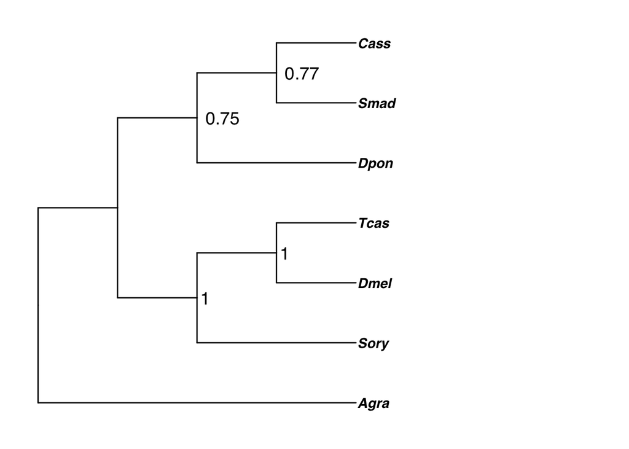

```r
tree6 = read.tree("/Users/kosukesano/bio/240912_ASTRAL.tre")

p=ggtree(tree6)+
  xlim(0, 7)+
  theme(text = element_text(face = "italic"))+
  geom_tiplab(fontface = 4, linesize=3.0) + # Make tip labels italic
  geom_nodelab(hjust = -0.2, node = "internal", size = 5) +
  #geom_text(aes(label=node), hjust=-.2)+
  theme_tree()
p
```

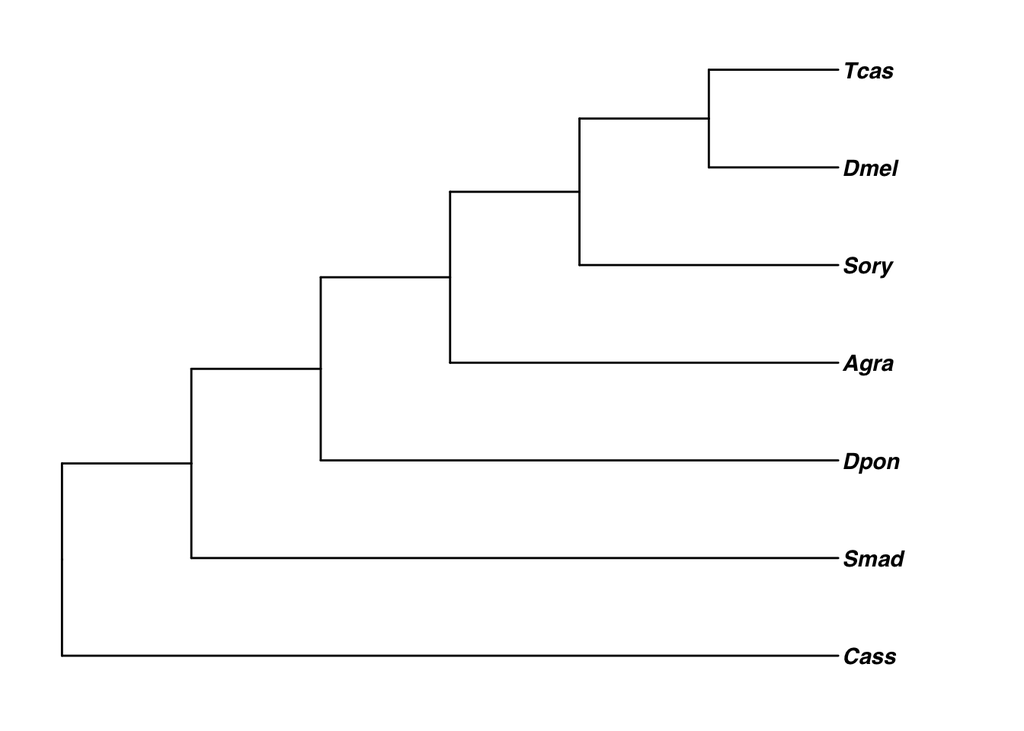

```r
tree7= read.tree("/Users/kosukesano/bio/240912_ASTRAL_Optimal_tree.tre")
p=ggtree(tree7)+
  xlim(0, 7)+
  theme(text = element_text(face = "italic"))+
  geom_tiplab(fontface = 4, linesize=3.0) + # Make tip labels italic
  geom_nodelab(hjust = -0.2, node = "internal", size = 5) +
  #geom_text(aes(label=node), hjust=-.2)+
  theme_tree()
p
```

**ショウジョウバエがあり得ない位置にいる！？**

OG番号から配列を取ってくる際に種名をつけるところをミスっているのでは？昨日の`New_Manualphylo_3.py`をこれにも適用してもう一度やってみる。

```bash
### align.shの中身

#!/bin/sh
#$ -S /bin/bash
#$ -cwd
#$ -v PATH
awk '{print($1)}' $1 | while read x; do #引数に前述のOG_list.txtなどのOGリストを指定する。
    mafft --auto $x > $x.maffted.fa
    trimal -in $x.maffted.fa -out $x.maffted.trimed.fa -keepheader -htmlout $x.maffted.trimed.fa.html -automated1
done
```

```bash
###New_Maunalphylo_3.pyの中身

import os
from Bio import SeqIO

# 処理するディレクトリのパス
input_dir = '~/tools/for_orthofinder/Smad_Agra_Cass_Dpon_Sory_Tcas_Dmel_fasta_dir/OrthoFinder/Results_Sep03/ManualPhylo_data'
input_dir = os.path.expanduser(input_dir)

# ディレクトリ内のファイルをリスト
files = [f for f in os.listdir(input_dir) if f.endswith('.maffted.trimed.fa')]

# 各ファイルに対して処理を適用
for file in files:
    input_file = os.path.join(input_dir, file)

    # 出力ファイルのパス
    og_number = file.split('.')[0]  # OG番号を取得
    output_file = os.path.join(input_dir, f"{og_number}.maffted.trimed.edit.fa")

    # ファイルの読み込みと書き換え
    with open(output_file, 'w') as outfile:
        for record in SeqIO.parse(input_file, 'fasta'):
            header = record.description
            seq = str(record.seq)

            # ヘッダーが「>g」で始まる場合、「>Smad」に置き換え
            if header.startswith("g"):
                new_header = ">Smad"

            # ヘッダーが「]」で終わる場合、指定の形式に変換
            elif header.endswith("]"):
                # 「[]」内の最初の1文字とスペース後の3文字を抽出
                within_brackets = header.split('[')[1].split(']')[0]
                first_letter = within_brackets[0]
                space_after = within_brackets.split()[-1][:3]
                new_header = f">{first_letter}{space_after}"

            else:
                new_header = header

            # 新しいヘッダーと配列を出力ファイルに書き込む
            outfile.write(f"{new_header}\n{seq}\n")

        # ジョブの進行状況を出力
        print(f"Processed: {file}")

print("全てのファイルが処理されました。")
```

これをどれも実行した上で、改めて`makealltree.sh`を`qsub`で投げた。

### 0917

#### `New_Manualphylo_3.py`を使用した昆虫6種の`ASTRAL`

`~/tools/for_orthofinder/Smad_Agra_Cass_Dpon_Sory_Tcas_fasta_dir/OrthoFinder/Results_Jun25/SCOwithOneZero_Manualphylo_data`下で`New_Manualphylo_3.py`を実行し、その上で`IQ-TREE`にかけた結果が出てきた。

この最終出力である`all_trees.nwk`を`~/tools/for_ASTRAL/Astral/data/new_6sp_withOneZero/`にコピー。

**注意！**

元のヘッダーで種名以外の部分に`[]`が使われており、`uubi`という種が新たに創造されていた。２つ３つだったので`nano`で手動編集し修正した。

このファイルを`modify.py`にかけ、OG番号を削除。`ASTRAL`にかける。

出力ファイルは`~/tools/for_ASTRAL/Astral/240917_6sp_withOneZero_result`に格納。その中身は以下の通り。

```bash
### ~/tools/for_ASTRAL/Astral/240917_6sp_withOneZero_result/out.logの中身の一部

======== Running the main analysis
Number of taxa: 6 (6 species)
Taxa: [Agra, Cass, Dpon, Smad, Sory, Tcas]
Taxon occupancy: {Cass=1837, Sory=1902, Tcas=1856, Agra=1921, Smad=1843, Dpon=1909}
Number of gene trees: 1950
432 trees have missing taxa
Calculating quartet distance matrix (for completion of X)
Species tree distances calculated ...
Will attempt to complete bipartitions from X before adding using a distance matrix.
Building set of clusters (X) from gene trees
```

各種に欠損がちびちび入ってるから無事取れてそう？

これにより描かれた系統樹は以下の通り。

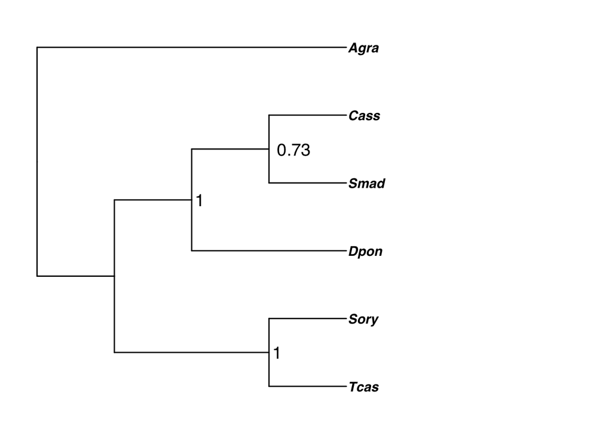

```r
tree8= read.tree("/Users/kosukesano/bio/240917_6sp_withOneZero_ASTRAL.tre")
p=ggtree(tree8)+
  xlim(0, 7)+
  theme(text = element_text(face = "italic"))+
  geom_tiplab(fontface = 4, linesize=3.0) + # Make tip labels italic
  geom_nodelab(hjust = -0.2, node = "internal", size = 5) +
  #geom_text(aes(label=node), hjust=-.2)+
  theme_tree()
p=flip(p, 2, 3)
p=flip(p, 1, 8)
p
```

`Agra`が変なとこにいるのは変わらない.

#### `New_Manualphylo_3.py`を使用した昆虫７種の`ASTRAL`

ショウジョウバエも入れた時の結果。

`all_trees.nwk`を`~/tools/for_ASTRAL/Astral/data/new_7sp/`にコピー。

**注意！**

これも同様に元のヘッダーで種名以外の部分に`[]`が使われており、`uubi`という種が新たに創造されていた。また`__`という種もあった。２つ３つだったので`nano`で手動編集し修正した。

このファイルを`modify.py`にかけ、OG番号を削除。`ASTRAL`にかける。出力ファイルは`~/tools/for_ASTRAL/Astral/240917_7sp_result`に格納。その中身は以下の通り。

```bash
### ~/tools/for_ASTRAL/Astral/240917_7sp_result/out.logの中身の一部

======== Running the main analysis
Number of taxa: 7 (7 species)
Taxa: [Agra, Cass, Dpon, Dmel, Tcas, Sory, Smad]
Taxon occupancy: {Dmel=630, Cass=630, Sory=630, Tcas=630, Agra=630, Smad=630, Dpon=630}
Number of gene trees: 630
0 trees have missing taxa
Calculating quartet distance matrix (for completion of X)
Species tree distances calculated ...
Building set of clusters (X) from gene trees
------------------------------
```

これにより描かれた系統樹は以下の通り。

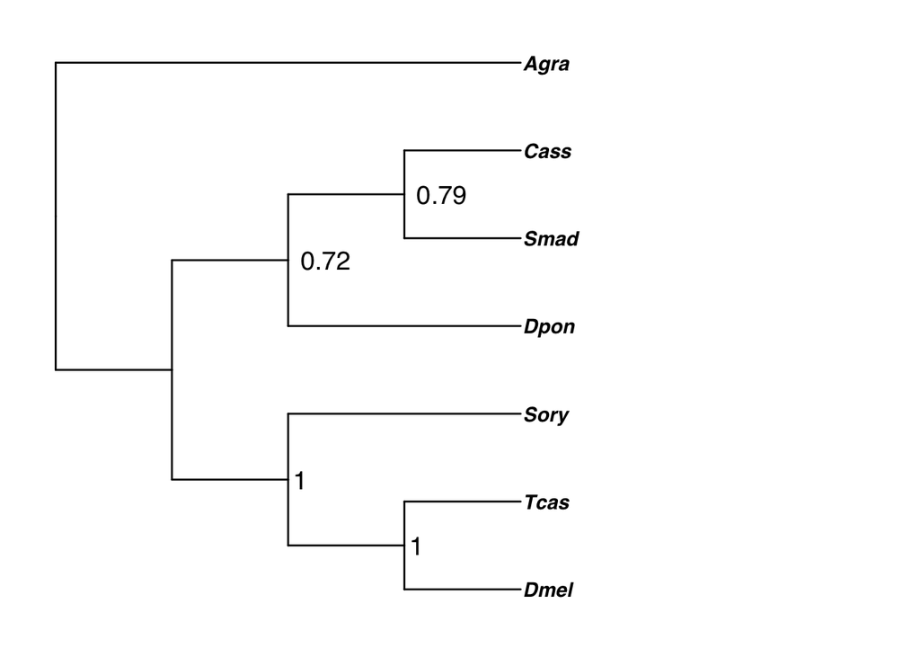

```r
tree9= read.tree("/Users/kosukesano/bio/240917_7sp_ASTRAL.tre")
p=ggtree(tree9)+
  xlim(0, 7)+
  theme(text = element_text(face = "italic"))+
  geom_tiplab(fontface = 4, linesize=3.0) + # Make tip labels italic
  geom_nodelab(hjust = -0.2, node = "internal", size = 5) +
  #geom_text(aes(label=node), hjust=-.2)+
  theme_tree()
p=flip(p, 2, 11)
p=flip(p, 1, 9)
p
```

`Smad`・`Cass`・`Dpon`のクレード関係は先行研究と違ってるね。`Agra`はそもそも元データがダメか？

#### 6種の昆虫のミトコンドリアCO1遺伝子での系統樹推定

`~/tools/for_orthofinder/CO1_6sp/data`ディレクトリを作成。

その下で`Smad.fasta`を作成した。[参照元はこちら](https://www.ncbi.nlm.nih.gov/nuccore/LC778257.1?report=fasta)

`Cass.fasta`[参照元はこちら](https://www.ncbi.nlm.nih.gov/nuccore/KY486447.1?report=fasta)

`Dpon.fasta`[参照元はこちら](https://www.ncbi.nlm.nih.gov/nuccore/AF067987.1?report=fasta)

`Agra.fasta`[参照元はこちら](https://www.ncbi.nlm.nih.gov/nuccore/KY620200.1?report=fasta)

`Sory.fasta`[参照元はこちら](https://www.ncbi.nlm.nih.gov/nuccore/OQ996824.1?report=fasta)

`Tcas.fasta`[参照元はこちら](https://www.ncbi.nlm.nih.gov/nuccore/XM_966568.5?report=fasta)

これを１つにまとめたファイル、`COI.fasta`を`~/tools/for_orthofinder/CO1_6sp`に作成した。

これについて、`align.sh`を実行した。`align.sh`のスクリプトは以下の通り。

```bash
### align.shの中身

#!/bin/sh
#$ -S /bin/bash
#$ -cwd
#$ -v PATH

# COI.fasta に対してMAFFTとTrimAlを実行
mafft --auto COI.fasta > COI.maffted.fa
trimal -in COI.maffted.fa -out COI.maffted.trimed.fa -htmlout COI.maffted.trimed.fa.html -automated1
```

さらに、これについて`IQ-TREE`で遺伝子系統樹を描いた。実行スクリプト`IQ_TREE.sh`は以下の通り。

```bash
### IQ_TREE.shの中身

#!/bin/bash
#$ -S /bin/bash
#$ -cwd
#$ -l intel
#$ -pe def_slot 16
echo start at
date

# Singularityイメージのパスを指定
SINGULARITY_IMAGE="/usr/local/biotools/i/iqtree:2.3.3--h21ec9f0_0"

# 処理するファイルを指定
file="COI.maffted.trimed.fa"

# ファイル名から拡張子を除いたベース名を取得
base_name=$(basename $file .maffted.trimed.fa)

# Singularityを使用してIQ-TREEを実行して系統樹を作成
singularity exec -e $SINGULARITY_IMAGE iqtree2 -s $file -nt AUTO -bb 1000 -cptime 600 -pre ${base_name}

# 作成された系統樹ファイル (.treefile) を確認
if [ -f ${base_name}.treefile ]; then
    echo "Tree for ${base_name} has been successfully created."
else
    echo "Error: ${base_name}.treefile not found" >&2
fi

echo "Process completed."

date
```

これを`qsub`で投げた。

#### 元データのヘッダーを書き換えた状態での系統樹推定

`~/tools/for_orthofinder/Smad_Agra_Cass_Dpon_Sory_Tcas_fasta_dir`ディレクトリから`.fasta`ファイルを取得し、「種名」＋「遺伝子ID」のみに書き換えて`~/tools/for_orthofinder/RemakeHedder_6sp`ディレクトリに保存するスクリプト`edit.py`を`~/tools/for_orthofinder/RemakeHedder_6sp`の下で作成。

```bash
### edit.pyの中身

import os
from Bio import SeqIO

# 入力ディレクトリと出力ディレクトリのパス
input_dir = '../Smad_Agra_Cass_Dpon_Sory_Tcas_fasta_dir/'
output_dir = '../RemakeHedder_6sp/'

# 出力ディレクトリが存在しない場合は作成
if not os.path.exists(output_dir):
    os.makedirs(output_dir)

# 入力ディレクトリ内のすべての .fasta ファイルを処理
for input_file in os.listdir(input_dir):
    if input_file.endswith('.fasta'):
        input_path = os.path.join(input_dir, input_file)
        output_path = os.path.join(output_dir, input_file)

        # 入力ファイルを読み込み、条件に基づいて書き換えた内容を出力ファイルに保存
        with open(output_path, 'w') as outfile:
            for record in SeqIO.parse(input_path, 'fasta'):
                header = record.description
                seq = str(record.seq)

                # ヘッダーが「g」で始まる場合
                if header.startswith("g"):
                    # 新しいヘッダーは「>Smad」 + 「元のヘッダーの番号」
                    number = header.split()[0]  # ヘッダーの最初の番号部分を取得
                    new_header = f">Smad_{number}"

                # ヘッダーが「]」で終わる場合
                elif header.endswith("]"):
                    # ヘッダーの最後の「[]」内の英字を抽出
                    within_brackets = header.split('[')[-1].split(']')[0]
                    first_letter = within_brackets[0]  # 最初の1文字
                    space_after = within_brackets.split()[-1][:3]  # スペース後の3文字

                    # 元のヘッダーから最初の「>」の次の文字から最初の「 」までの部分を取得
                    first_part = header.split()[0][1:]
                    new_header = f">{first_letter}{space_after}_{first_part}"

                else:
                    new_header = f">{header.split()[0]}"

                # 新しいヘッダーと配列を出力ファイルに書き込む
                outfile.write(f"{new_header}\n{seq}\n")

        print(f"{output_path} に保存しました。")
```

これを実行。

```bash
(MPT) kosukesano@at137:~/tools/for_orthofinder/RemakeHedder_6sp$ python edit.py
../RemakeHedder_6sp/Tcas.fasta に保存しました。
../RemakeHedder_6sp/Agra.fasta に保存しました。
../RemakeHedder_6sp/Smad.fasta に保存しました。
../RemakeHedder_6sp/Cass.fasta に保存しました。
../RemakeHedder_6sp/Dpon.fasta に保存しました。
../RemakeHedder_6sp/Sory.fasta に保存しました。
(MPT) kosukesano@at137:~/tools/for_orthofinder/RemakeHedder_6sp$ ls
Agra.fasta  Cass.fasta  Dpon.fasta  Smad.fasta  Sory.fasta  Tcas.fasta  edit.py
```

`~/tools/for_orthofinder`で`Orthofinder`の実行スクリプト`Orthofinder_240917_RH.sh`を記述。

```bash
### Orthofinder_240917_RH.shの中身

#$ -S /bin/bash
#$ -cwd
#$ -pe def_slot 5
#$ -l medium
#$ -l s_vmem=64G
#$ -l mem_req=64G
echo start at
date


singularity exec /usr/local/biotools/o/orthofinder:2.5.4--hdfd78af_0 orthofinder -f ~/tools/for_orthofinder/RemakeHedder_6sp -t 5 -a 5

date
```

これを`qsub`で投げた。

#### Pissodes strobiのソフトマスク

[参照元はこちら](https://www.ncbi.nlm.nih.gov/datasets/genome/GCA_016904865.1/)

生データは`~/tools/for_softmask/nama_data/Pstr_data`に格納した。

```bash
(MPT) kosukesano@at137:~/tools/for_softmask/nama_data/Pstr_data$ ls
GCA_016904865.1  assembly_data_report.jsonl  data_summary.tsv  dataset_catalog.json
(MPT) kosukesano@at137:~/tools/for_softmask/nama_data/Pstr_data$
```

ソフトマスク用のディレクトリ`~/tools/for_softmask/Pstr_softmask`を作成。

```bash
(MPT) kosukesano@at137:~/tools/for_softmask$ mkdir Pstr_softmask
(MPT) kosukesano@at137:~/tools/for_softmask$ cd Pstr_softmask/
(MPT) kosukesano@at137:~/tools/for_softmask/Pstr_softmask$ ls
(MPT) kosukesano@at137:~/tools/for_softmask/Pstr_softmask$ source ~/tools/pyenv_env/EDTA_profile
```

データベースの構築

```bash
(MPT) kosukesano@at137:~/tools/for_softmask/Pstr_softmask$ source ~/tools/pyenv_env/EDTA_profile

(EDTA2) kosukesano@at137:~/tools/for_softmask/Pstr_softmask$ BuildDatabase -name Pstr_BLAST_DATABASE_PREFIX /home/kosukesano/tools/for_softmask/nama_data/Pstr_data/GCA_016904865.1/GCA_016904865.1_GSC_weevil_1.0_genomic.fna
Building database Pstr_BLAST_DATABASE_PREFIX:
  Reading /home/kosukesano/tools/for_softmask/nama_data/Pstr_data/GCA_016904865.1/GCA_016904865.1_GSC_weevil_1.0_genomic.fna...
Number of sequences (bp) added to database: 84140 ( 2025024129 bp )
(EDTA2) kosukesano@at137:~/tools/for_softmask/Pstr_softmask$
```

`RepeatModeler`の実行

`Pstr_RepeatModeler.sh`を作成し、`qsub`で投げた。シェルスクリプトの中身は以下の通り。

```bash
#$ -S /bin/bash
#$ -cwd
#$ -l medium
#$ -pe def_slot 24
#$ -l s_vmem=64G
#$ -l mem_req=64G
echo start at
date

source ~/tools/pyenv_env/EDTA_profile

RepeatModeler -database Pstr_BLAST_DATABASE_PREFIX  -pa 6
date
```

#### Elaeidobius kamerunicusのソフトマスク

[参照元はこちら](https://www.ncbi.nlm.nih.gov/datasets/genome/GCA_014849505.1/)

生データは`~/tools/for_softmask/nama_data/Ekam_data`に格納した。

ソフトマスク用のディレクトリ`~/tools/for_softmask/Ekam_softmask`を作成。

データベースの構築

```bash
(EDTA2) kosukesano@at137:~/tools/for_softmask/Ekam_softmask$ BuildDatabase -name Ekam_BLAST_DATABASE_PREFIX /home/kosukesano/tools/for_softmask/nama_data/Ekam_data/GCA_014849505.1/GCA_014849505.1_AAL_Ekam_1.0_genomic.fna
Building database Ekam_BLAST_DATABASE_PREFIX:
  Reading /home/kosukesano/tools/for_softmask/nama_data/Ekam_data/GCA_014849505.1/GCA_014849505.1_AAL_Ekam_1.0_genomic.fna...
Number of sequences (bp) added to database: 364527 ( 269635327 bp )
(EDTA2) kosukesano@at137:~/tools/for_softmask/Ekam_softmask$
```

`RepeatModeler`の実行

`Ekam_RepeatModeler.sh`を作成し、`qsub`で投げた。シェルスクリプトの中身は以下の通り。

```bash
#$ -S /bin/bash
#$ -cwd
#$ -l medium
#$ -pe def_slot 24
#$ -l s_vmem=64G
#$ -l mem_req=64G
echo start at
date

source ~/tools/pyenv_env/EDTA_profile

RepeatModeler -database Ekam_BLAST_DATABASE_PREFIX  -pa 6
date
```

### 0918

#### 6種の昆虫ゲノムについて、`all_seq.fa`のヘッダー行を書き換えて再度系統樹作成

OG番号から種ごとに配列を取ってくる際、何かやらかしているのでは？そこのケア。

`~/tools/for_orthofinder/Smad_Agra_Cass_Dpon_Sory_Tcas_fasta_dir/OrthoFinder/Results_Jun25/RenameHedder`というディレクトリを作り、そこで作業を行う。

まず新しい`OG_list.txt`を作る。前の`OG_list.txt`は種名がわからなかったので種名もつけるようにする。それを実行するスクリプトは`makeOGlist.py`。

```bash
### makeOGlist.pyの中身

# ファイルを読み込む
input_file = '../ManualPhylo_data/OG_list.txt'
output_file = '../RenameHedder/New_OG_list.txt'

# 種の接頭辞をリストで定義
prefixes = ['Agra_', 'Cass_', 'Dpon_', 'Smad_', 'Sory_', 'Tcas_']

# 出力ファイルに書き込み
with open(input_file, 'r') as fin, open(output_file, 'w') as fout:
    for line in fin:
        parts = line.strip().split()  # 各行をスペースで区切る
        new_line = parts[0] + ' ' + ' '.join([f'{prefixes[i]}{parts[i+1]}' for i in range(6)])  # プレフィックスを追加
        fout.write(new_line + '\n')  # 新しい行をファイルに書き込む
```

最終出力は`New_OG_list.txt`

次に新しい`allseq.fa`を作る。こちらはヘッダーにいらないアノテーションの説明などが入っているので、遺伝子IDと種名のみにする。その実行スクリプト`edit_allseq.py`は以下の通り。

```bash
### edit_allseq.pyの中身

  GNU nano 6.2                                                                         edit_allseq.py
from Bio import SeqIO

# 入力ファイルと出力ファイルのパス
input_file = '../../../../make_philo_tree/output_directory/all_seq.fa'
output_file = 'new_all_seq.fa'

# 入力ファイルを読み込み、条件に基づいて書き換えた内容を出力ファイルに保存
with open(output_file, 'w') as outfile:
    for record in SeqIO.parse(input_file, 'fasta'):
        header = record.description
        seq = str(record.seq)

        # ヘッダーが「>g」で始まる場合
        if header.startswith("g"):
            # 新しいヘッダーは「>Smad」 + 「元のヘッダーの番号」
            number = header.split()[0]  # ヘッダーの最初の番号部分を取得
            new_header = f">Smad_{number}"

        # ヘッダーが「]」で終わる場合
        elif header.endswith("]"):
            # ヘッダーの最後の「[]」内の英字を抽出
            within_brackets = header.split('[')[-1].split(']')[0]
            first_letter = within_brackets[0]  # 最初の1文字
            space_after = within_brackets.split()[-1][:3]  # スペース後の3文字

            # 元のヘッダーから最初の「>」の次の文字から最初の「 」までの部分を取得
            first_part = header.split()[0][0:]
            new_header = f">{first_letter}{space_after}_{first_part}"

        else:
            new_header = f">{header.split()[0]}"

        # 新しいヘッダーと配列を出力ファイルに書き込む
        outfile.write(f"{new_header}\n{seq}\n")

print(f"{output_file} に保存しました。")
```

これの最終出力は`new_all_seq.fa`

続いて各OGごとに.fastaファイルを作る。その実行スクリプト`New_Manualphylo_2.py`は以下の通り。

```bash
### New_Manualphylo_2.pyの中身

# ライブラリのインポート
import os

# ファイルのパス
og_list_file = "New_OG_list.txt"
sequence_file = "new_all_seq.fa"

# sequence_fileをメモリに読み込む
with open(sequence_file, "r") as seq_file:
    sequences = seq_file.read().splitlines()

# ヘッダーとシーケンスのマッピング
seq_dict = {}
header = ""
for line in sequences:
    if line.startswith(">"):
        header = line[1:].strip()  # ヘッダー行（'>'を除く）
        seq_dict[header] = ""
    else:
        seq_dict[header] += line.strip()

# New_OG_list.txtを処理
with open(og_list_file, "r") as og_file:
    og_lines = og_file.readlines()

# 1行ごとに処理を行う
for og_line in og_lines:
    og_data = og_line.strip().split()  # 空白で区切る
    og_number = og_data[0]  # OG番号
    gene_ids = og_data[1:]  # 遺伝子IDのリスト

    # 出力ファイルを作成
    output_file = f"{og_number}.fa"
    with open(output_file, "w") as out_file:
        # 各遺伝子IDについて処理
        for gene_id in gene_ids:
            if gene_id in seq_dict:
                # 一致したヘッダーと配列データを書き込む
                out_file.write(f">{gene_id}\n")
                out_file.write(f"{seq_dict[gene_id]}\n")

    # 経過報告
    print(f"{og_number}.fa の作成が完了しました。")

print("すべての処理が完了しました。")
```

続いて各OGのファイルに`MAFFT`をかける。そのスクリプト`align.sh`は以下の通り。

```bash
### align.shの中身

#!/bin/sh
#$ -S /bin/bash
#$ -cwd
#$ -v PATH
awk '{print($1)}' $1 | while read x; do #引数に前述のOG_list.txtなどのOGリストを指定する。
    mafft --auto $x.fa > $x.maffted.fa
    trimal -in $x.maffted.fa -out $x.maffted.trimed.fa -htmlout $x.maffted.trimed.fa.html -automated1
done
```

`MAFFT`によって得られたファイルを`IQ-TREE`の入力に沿うよう、遺伝子IDの部分を切る。そのスクリプト`Manualphylo_4.py`は以下の通り。

```bash
### Manualphylo_4.pyの中身

import os

# ファイルのヘッダーを変更する関数
def modify_headers(input_file, output_file):
    with open(input_file, 'r') as infile, open(output_file, 'w') as outfile:
        for line in infile:
            if line.startswith(">"):
                # ヘッダー行の最初の四文字を抽出して書き換え
                outfile.write(f">{line[1:5]}\n")
            else:
                outfile.write(line)

# 作業ディレクトリ内のすべての ".maffted.trimed.fa" ファイルに対して処理を適用
def process_directory(directory):
    for filename in os.listdir(directory):
        if filename.endswith(".maffted.trimed.fa"):
            input_file = os.path.join(directory, filename)
            output_file = os.path.join(directory, filename.replace(".maffted.trimed.fa", ".maffted.trimed.edit.fa"))
            modify_headers(input_file, output_file)
            print(f"Processed: {filename}")

# 実行するディレクトリを指定（例：カレントディレクトリ）
process_directory(".")
```

これを実行した後に`makealltree.sh`を作成、ジョブとして投げた。